# 第13講 回帰分析

変数間の関係を推測する

Published

July 10, 2026

## 準備

以下で利用する共通パッケージを読み込む．

```r
library(conflicted)  # 関数名の衝突を警告
conflicts_prefer(    # 優先的に使う関数を指定
    dplyr::filter(),
    dplyr::select(),
    dplyr::lag(),
    )
library(tidyverse)
library(broom)       # tidy(), gloance(), augment() を利用する
#' 日本語を用いるので macOS ではフォントの設定を行う
if(Sys.info()["sysname"] == "Darwin") { # macOS か調べて日本語フォントを指定
    theme_update(text = element_text(family = "HiraginoSans-W4"))
    update_geom_defaults("text", list(family = theme_get()$text$family))
    update_geom_defaults("label", list(family = theme_get()$text$family))}
```

## 回帰分析の確率シミュレーション

### 問題

回帰分析におけるモデルの推定量の精度に関する 確率シミュレーションを考えなさい．

### 解答欄

### 解答例

人工データによる回帰モデルの推定を行う． 以下のモデルのパラメタは適当に変更してよい．

```r
alpha <- 2    # 切片
beta  <- 3    # 回帰係数
n <- 20       # データ数
sigma <- 0.5  # 誤差の標準偏差
```

データを生成する．

```r
x <- runif(n, min = -1, max = 1) # 説明変数 (区間[-1,1]を想定)
epsilon <- rnorm(n, sd = sigma)  # 誤差 (正規分布)
y <- alpha + beta * x + epsilon
```

データの視覚化を行う

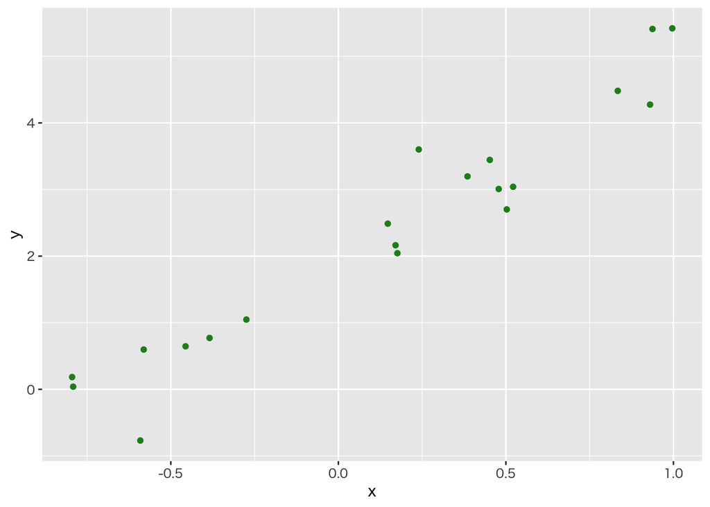

```r
toy_data <- tibble(x = x, y = y)
gg <- # 後で描き加えるため保存しておく
    toy_data |>
    ggplot(aes(x = x, y = y)) +
    geom_point(colour = "forestgreen")
print(gg)
```

回帰式の推定を行う．

```r
toy_lm <- lm(y ~ x, data = toy_data)
coef(toy_lm) # 推定された係数の取得
```

```
(Intercept)           x
   1.964412    2.930838
```

推定された回帰分析の結果を表示する． これらの方法については回帰係数の有意性検定でも詳述する．

```r
#' base R での情報の表示
toy_lm |> summary() # さまざまな情報がlist形式
```

```
Call:
lm(formula = y ~ x, data = toy_data)

Residuals:
     Min       1Q   Median       3Q      Max
-1.00110 -0.37360  0.04538  0.34994  0.93357

Coefficients:
            Estimate Std. Error t value Pr(>|t|)
(Intercept)   1.9644     0.1167   16.83 1.85e-12 ***
x             2.9308     0.1966   14.91 1.42e-11 ***
---
Signif. codes:  0 '***' 0.001 '**' 0.01 '*' 0.05 '.' 0.1 ' ' 1

Residual standard error: 0.5063 on 18 degrees of freedom
Multiple R-squared:  0.9251,    Adjusted R-squared:  0.9209
F-statistic: 222.3 on 1 and 18 DF,  p-value: 1.425e-11
```

```r
#' tidyverse での情報の表示 (tibble形式)
toy_lm |> tidy()    # 推定された係数の情報
```

```
# A tibble: 2 × 5
  term        estimate std.error statistic  p.value
  <chr>          <dbl>     <dbl>     <dbl>    <dbl>
1 (Intercept)     1.96     0.117      16.8 1.85e-12
2 x               2.93     0.197      14.9 1.42e-11
```

```r
toy_lm |> glance()  # 推定に関するさまざまな情報
```

```
# A tibble: 1 × 12
  r.squared adj.r.squared sigma statistic  p.value    df logLik   AIC   BIC
      <dbl>         <dbl> <dbl>     <dbl>    <dbl> <dbl>  <dbl> <dbl> <dbl>
1     0.925         0.921 0.506      222. 1.42e-11     1  -13.7  33.4  36.4
# ℹ 3 more variables: deviance <dbl>, df.residual <int>, nobs <int>
```

```r
toy_lm |> augment() # 推定に用いられたデータの情報
```

```
# A tibble: 20 × 8
         y      x .fitted  .resid   .hat .sigma   .cooksd .std.resid
     <dbl>  <dbl>   <dbl>   <dbl>  <dbl>  <dbl>     <dbl>      <dbl>
 1  3.60    0.240   2.67   0.934  0.0514  0.466 0.0970        1.89
 2 -0.769  -0.591   0.232 -1.00   0.132   0.451 0.341        -2.12
 3  4.48    0.834   4.41   0.0735 0.122   0.521 0.00166       0.155
 4  2.49    0.148   2.40   0.0905 0.0500  0.520 0.000885      0.183
 5  4.27    0.930   4.69  -0.416  0.143   0.509 0.0658       -0.888
 6  2.16    0.171   2.46  -0.301  0.0501  0.516 0.00983      -0.610
 7  0.597  -0.581   0.262  0.335  0.129   0.514 0.0374        0.709
 8  2.70    0.503   3.44  -0.736  0.0693  0.487 0.0846       -1.51
 9  3.44    0.452   3.29   0.155  0.0642  0.519 0.00344       0.316
10  5.41    0.937   4.71   0.698  0.145   0.488 0.188         1.49
11  0.184  -0.795  -0.365  0.549  0.183   0.500 0.161         1.20
12  3.04    0.522   3.49  -0.452  0.0714  0.508 0.0330       -0.927
13  3.01    0.479   3.37  -0.359  0.0668  0.513 0.0193       -0.735
14  0.0392 -0.792  -0.355  0.395  0.182   0.510 0.0828        0.862
15  1.05   -0.274   1.16  -0.113  0.0765  0.520 0.00223      -0.232
16  0.770  -0.384   0.838 -0.0672 0.0922  0.521 0.000987     -0.139
17  2.04    0.176   2.48  -0.437  0.0501  0.509 0.0207       -0.886
18  5.42    0.996   4.88   0.535  0.159   0.501 0.126         1.15
19  0.645  -0.456   0.628  0.0173 0.104   0.521 0.0000760     0.0361
20  3.20    0.385   3.09   0.103  0.0587  0.520 0.00136       0.209
```

推定結果の視覚化を行う．

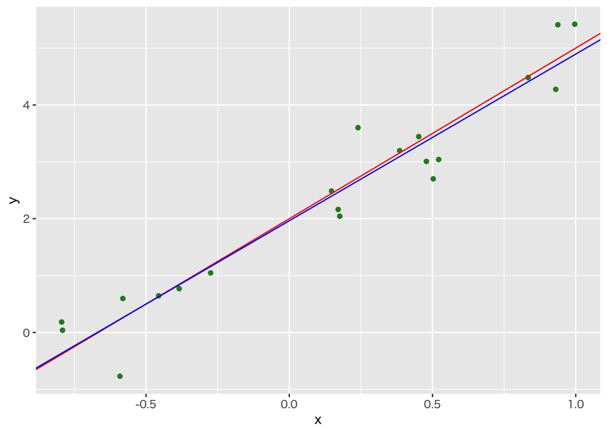

```r
gg +
    geom_abline(intercept = alpha,
                slope = beta,
                colour = "red") + # 真の回帰式
    geom_abline(intercept = coef(toy_lm)[1],
                slope = coef(toy_lm)[2],
                colour = "blue")  # 推定された回帰式
```

Monte-Carlo 実験を行う．

```r
mc_trial <- function(){
    epsilon <- rnorm(n, sd = sigma)
    y <- alpha + beta * x + epsilon # 説明変数は固定しておく
    est <- lm(y ~ x) # データフレームにせずに直接 x,y を渡す
    #' データフレームにする場合は以下のようにすればよい
    #' lm(y ~ x, data = tibble(x = x, y = y))
    return(coef(est))
}
mc_data <- # 実験結果をデータフレームに変換
    replicate(2000, mc_trial()) |> t() |> as_tibble() |>
    set_names(c("alpha", "beta")) # 列名を変更
```

推定値の分布を視覚化する．

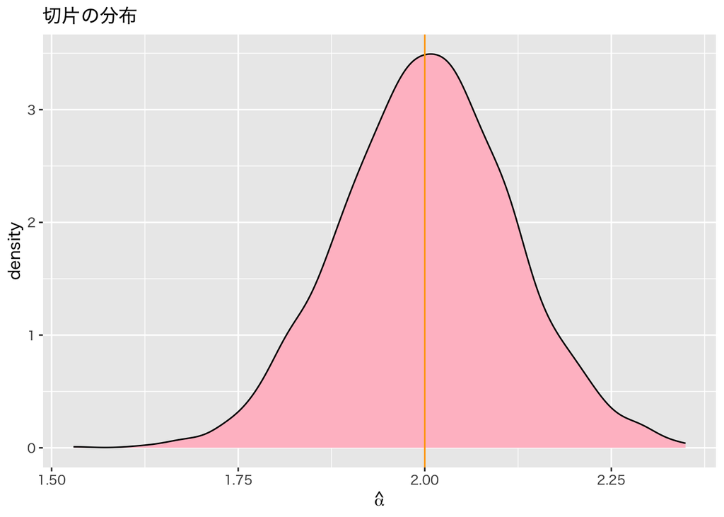

```r
mc_data |> # 切片
    ggplot(aes(x = alpha)) +
    geom_density(fill = "pink") +
    geom_vline(xintercept = alpha, colour = "orange") +
    labs(x = expression(hat(alpha)), title = "切片の分布")
```

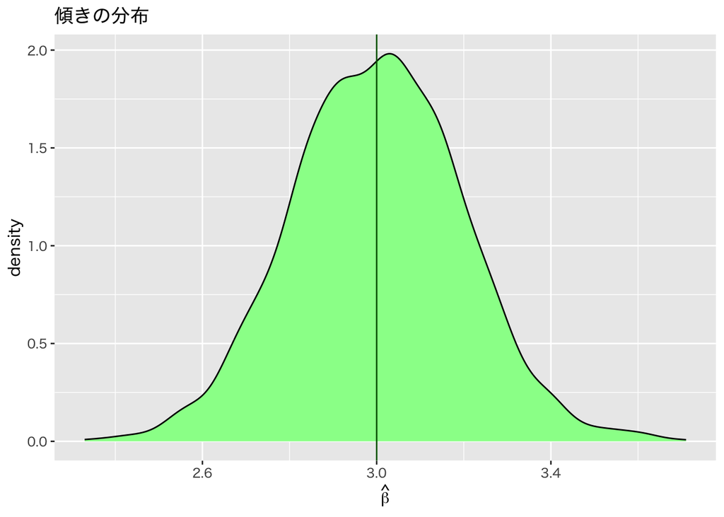

```r
mc_data |> # 傾き
    ggplot(aes(x = beta)) +
    geom_density(fill = "palegreen") +
    geom_vline(xintercept = beta, colour = "darkgreen") +
    labs(x = expression(hat(beta)), title = "傾きの分布")
```

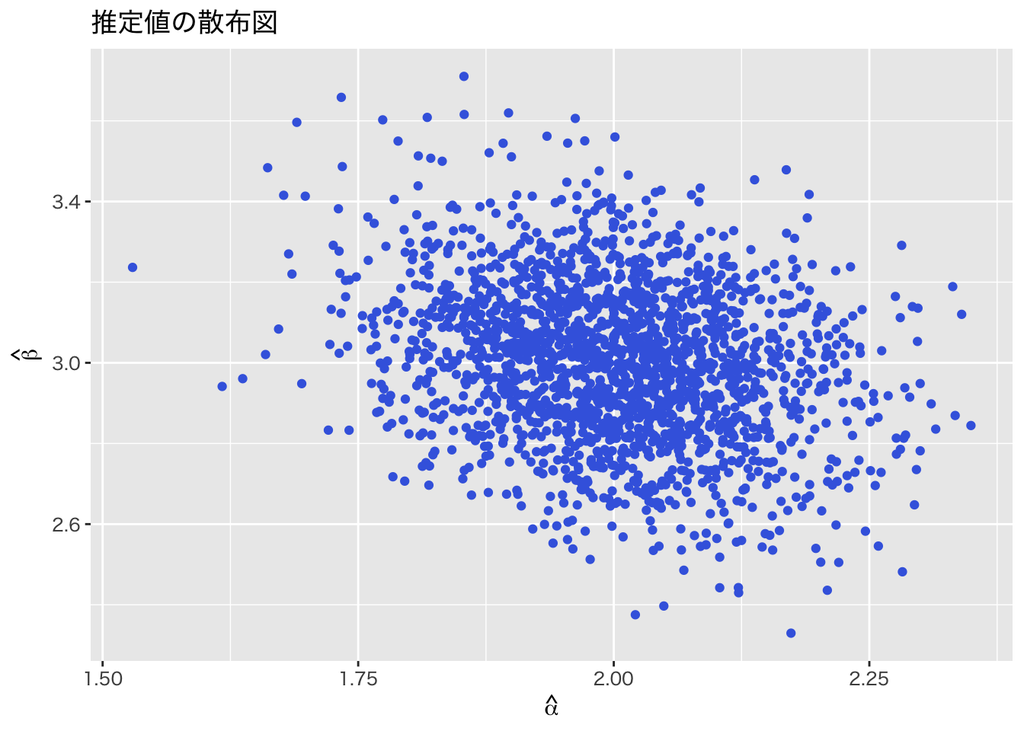

```r
mc_data |> # 散布図
    ggplot(aes(x = alpha, y = beta)) +
    geom_point(colour = "royalblue") +
    labs(x = expression(hat(alpha)),
         y = expression(hat(beta)),
         title = "推定値の散布図")
```

推定された回帰式のばらつきを表示する．

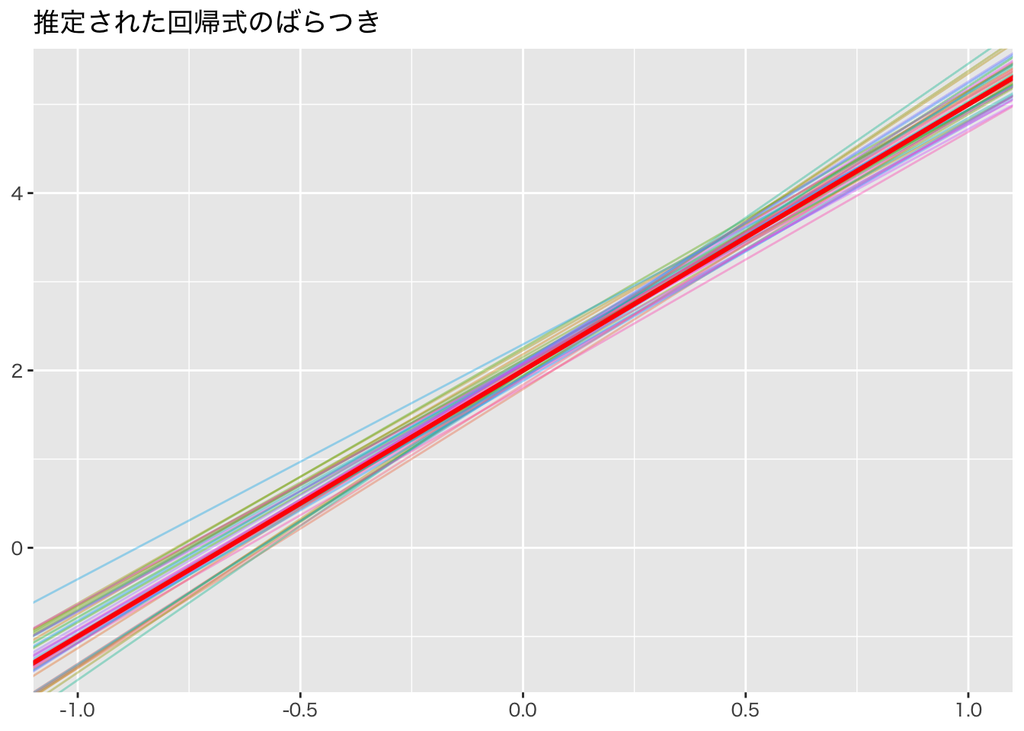

```r
mc_data |>
    slice_sample(n = 40) |> # Monte-Carlo 実験から40個ランダムに選択
    rowid_to_column() |>    # 番号列(rowid)を作成
    ggplot() +
    geom_abline(aes(intercept = alpha,
                    slope = beta,
                    colour = as_factor(rowid)), # 色を変える
                alpha = 0.4, # alpha値を低くして色を薄くする
                show.legend = FALSE) + # 凡例は表示しない
    geom_abline(intercept = alpha,
                slope = beta,
                colour = "red",
                linewidth = 1.1) + # 真の回帰式(太め)
    xlim(-1,1) + ylim(alpha-beta*1.1, alpha+beta*1.1) + # 描画範囲の指定
    labs(title = "推定された回帰式のばらつき")
```

同じ生成モデルでもデータによって推定結果がばらつくことがわかる．

## 回帰モデルの点推定

### 問題

東京の気象データを用いて， 必要であれば適当な期間を抽出し， 日射量から気温を説明する回帰モデルを構成しなさい．

### 解答欄

### 解答例

データの読み込みを行う．

```r
tw_data <- read_csv("data/tokyo_weather.csv")
```

データの散布図 (1年分) を描く．

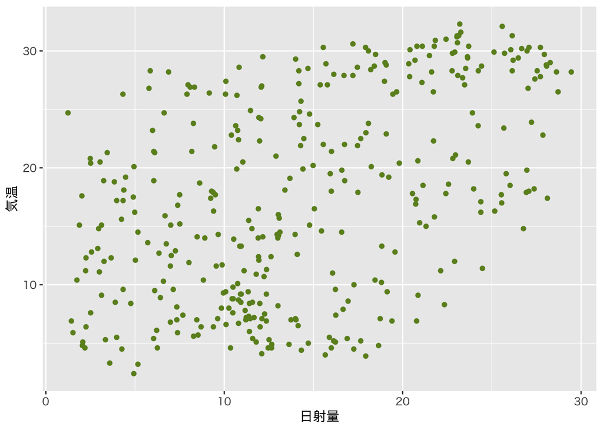

```r
tw_data |>
    ggplot(aes(x = solar, y = temp)) +
    geom_point(colour = "olivedrab") +
    labs(x = "日射量", y = "気温")
```

回帰式の推定を行い，その結果を表示する．

```r
tw_lm <- lm(temp ~ solar,    # 目的変数 ~ 説明変数
            data = tw_data) # 気温を日射量で説明
tw_lm |> summary()       # 結果の要約
```

```
Call:
lm(formula = temp ~ solar, data = tw_data)

Residuals:
     Min       1Q   Median       3Q      Max
-15.5652  -6.3738   0.0607   6.2991  15.7832

Coefficients:
            Estimate Std. Error t value Pr(>|t|)
(Intercept)  9.15181    0.86408   10.59   <2e-16 ***
solar        0.57520    0.05387   10.68   <2e-16 ***
---
Signif. codes:  0 '***' 0.001 '**' 0.01 '*' 0.05 '.' 0.1 ' ' 1

Residual standard error: 7.508 on 363 degrees of freedom
Multiple R-squared:  0.239, Adjusted R-squared:  0.2369
F-statistic:   114 on 1 and 363 DF,  p-value: < 2.2e-16
```

```r
tw_lm |> tidy()   # 係数とその統計量
```

```
# A tibble: 2 × 5
  term        estimate std.error statistic  p.value
  <chr>          <dbl>     <dbl>     <dbl>    <dbl>
1 (Intercept)    9.15     0.864       10.6 5.07e-23
2 solar          0.575    0.0539      10.7 2.50e-23
```

```r
tw_lm |> glance() # その他の統計量
```

```
# A tibble: 1 × 12
  r.squared adj.r.squared sigma statistic  p.value    df logLik   AIC   BIC
      <dbl>         <dbl> <dbl>     <dbl>    <dbl> <dbl>  <dbl> <dbl> <dbl>
1     0.239         0.237  7.51      114. 2.50e-23     1 -1253. 2511. 2523.
# ℹ 3 more variables: deviance <dbl>, df.residual <int>, nobs <int>
```

回帰直線を前の図に重ね描きして図示する．

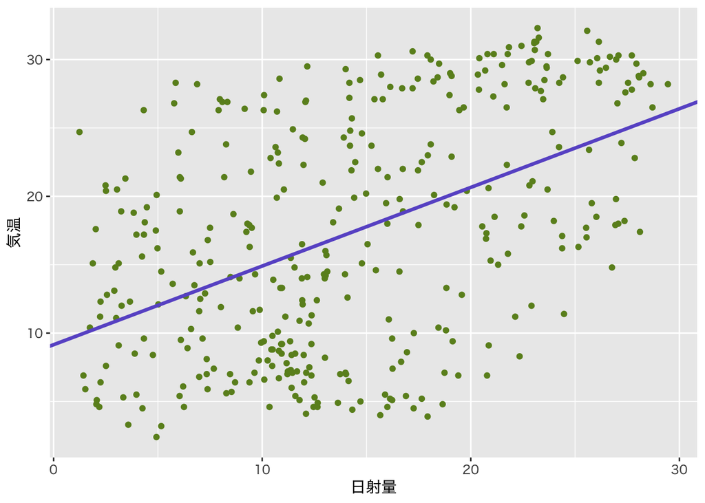

```r
last_plot() +
    geom_abline(intercept = coef(tw_lm)[1], # 切片
                slope = coef(tw_lm)[2],     # 回帰係数
                colour = "slateblue",
                linewidth = 1.2)
```

関数 `geom_smooth()` を用いることもできる．

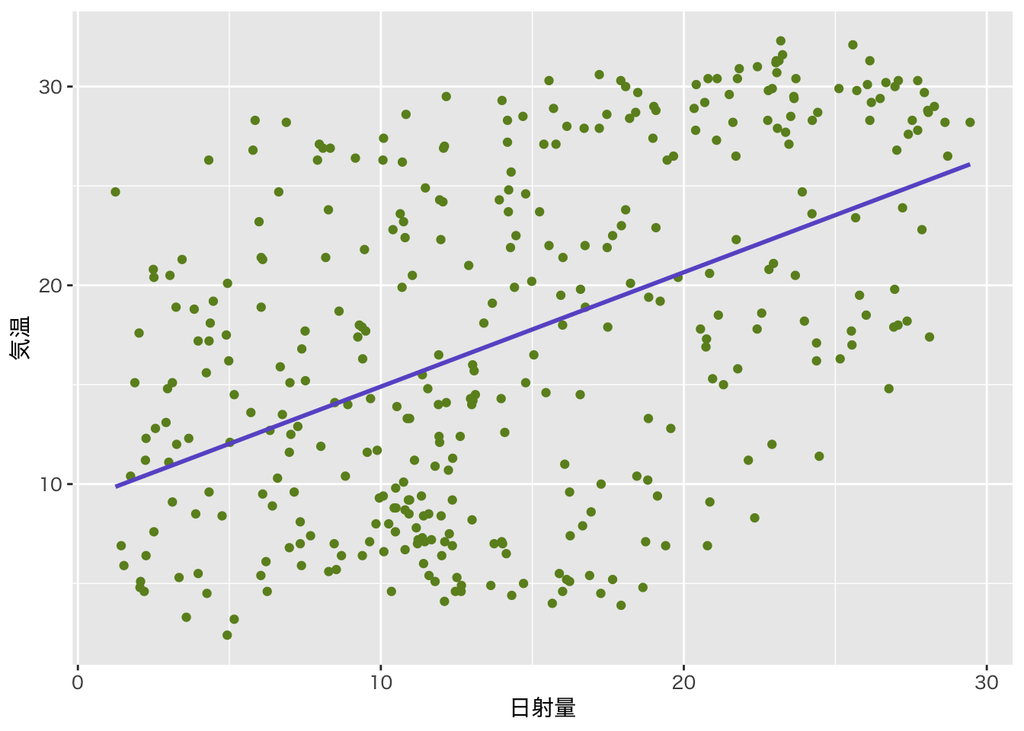

```r
tw_data |>
    ggplot(aes(x = solar, y = temp)) +
    geom_point(colour = "olivedrab") +
    geom_smooth(method = "lm", # 関数 lm を用いて信頼区間(平滑化方法)を計算
                se = FALSE,    # 信頼区間を付けない
                colour = "slateblue") +
    labs(x = "日射量", y = "気温")
```

期間を限って分析する． 夏のモデルのためのデータの散布図を描く．

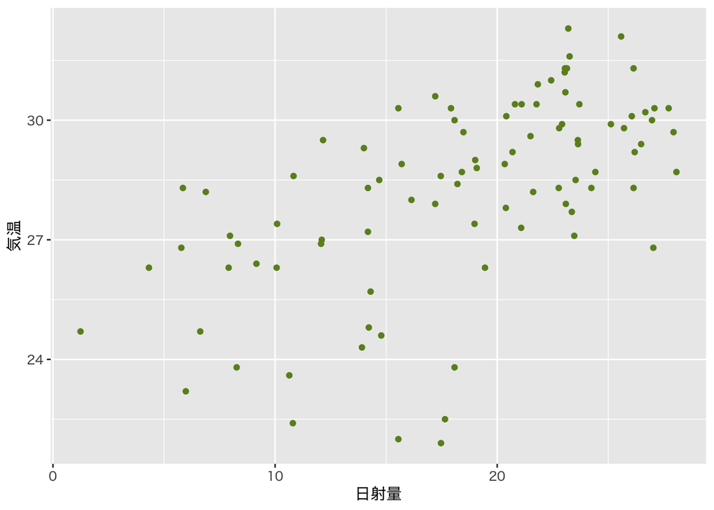

```r
tw_data |>
    filter(month %in% 7:9) |> # 7月-9月を抽出
    ggplot(aes(x = solar, y = temp)) +
    geom_point(colour = "olivedrab") +
    labs(x = "日射量", y = "気温")
```

回帰式の推定を行い，その結果を表示する．

```r
tw_lm2 <- lm(formula(tw_lm), # 前の式を利用
             data = tw_data,
             subset = month %in% 7:9) # 7月-9月を抽出
tw_lm2 |> summary()
```

```
Call:
lm(formula = formula(tw_lm), data = tw_data, subset = month %in%
    7:9)

Residuals:
    Min      1Q  Median      3Q     Max
-6.1047 -0.8730  0.2343  1.4268  3.0535

Coefficients:
            Estimate Std. Error t value Pr(>|t|)
(Intercept) 24.21845    0.60794  39.837  < 2e-16 ***
solar        0.21673    0.03119   6.949 5.61e-10 ***
---
Signif. codes:  0 '***' 0.001 '**' 0.01 '*' 0.05 '.' 0.1 ' ' 1

Residual standard error: 1.95 on 90 degrees of freedom
Multiple R-squared:  0.3492,    Adjusted R-squared:  0.342
F-statistic: 48.29 on 1 and 90 DF,  p-value: 5.61e-10
```

期間を限った分析は以下のように書くこともできる．

```r
tw_data |>
    filter(month %in% 7:9) |>    # 7月-9月を抽出
    lm(formula(tw_lm), data = _) # パイプ演算の内容を data に渡す
```

```
Call:
lm(formula = formula(tw_lm), data = filter(tw_data, month %in%
    7:9))

Coefficients:
(Intercept)        solar
    24.2184       0.2167
```

推定結果の可視化を行う．

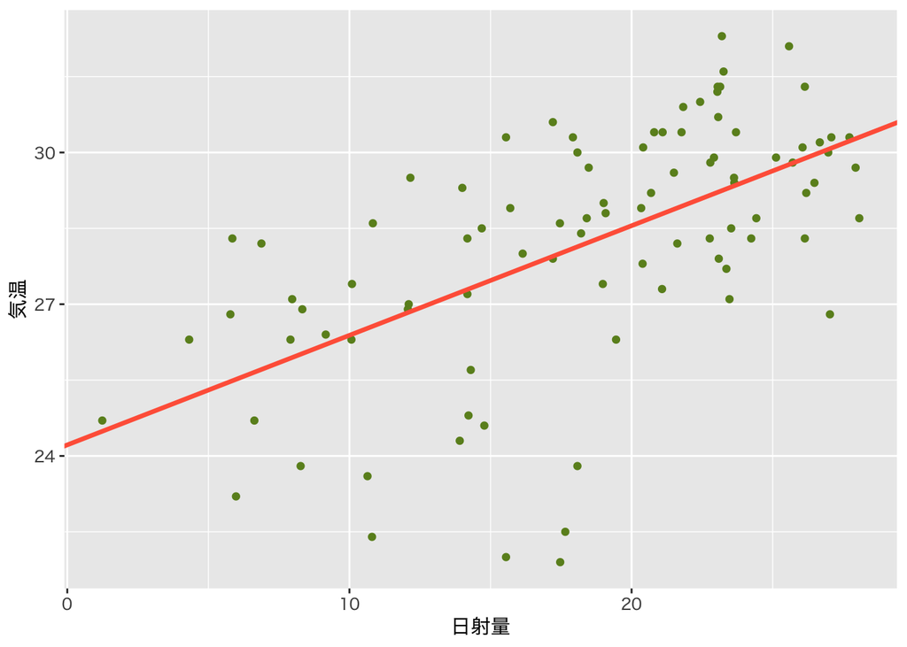

```r
last_plot() +
    geom_abline(intercept = coef(tw_lm2)[1],
                slope = coef(tw_lm2)[2],
                colour = "tomato",
                linewidth = 1.2)
```

関数 `geom_smooth()` を用いてもよい．

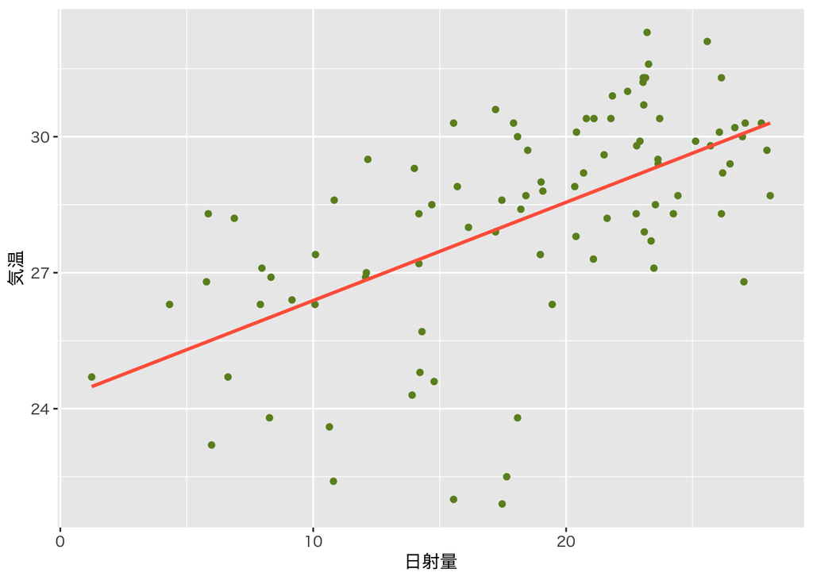

```r
tw_data |>
    filter(month %in% 7:9) |>
    ggplot(aes(x = solar, y = temp)) +
    geom_point(colour = "olivedrab") +
    geom_smooth(method = "lm",
                se = FALSE,
                colour = "tomato") +
    labs(x = "日射量", y = "気温")
```

全データのモデルと夏のモデルを比較する．

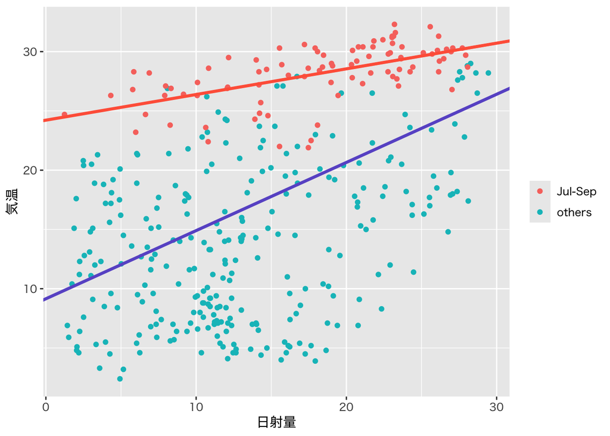

```r
tw_data |>
    mutate(summer = ifelse(month %in% 7:9,
                           "Jul-Sep", # 7月-9月のラベル
                           "others")) |>
    ggplot(aes(x = solar, y = temp, colour = summer)) +
    geom_point() +
    geom_abline(intercept = coef(tw_lm)[1],
                slope = coef(tw_lm)[2],
                colour = "slateblue",
                linewidth = 1.2) +
    geom_abline(intercept = coef(tw_lm2)[1],
                slope = coef(tw_lm2)[2],
                colour = "tomato",
                linewidth = 1.2) +
    labs(x = "日射量", y = "気温", colour = NULL)
```

関数 `geom_smooth()` を用いる場合は以下のようにすればよい．

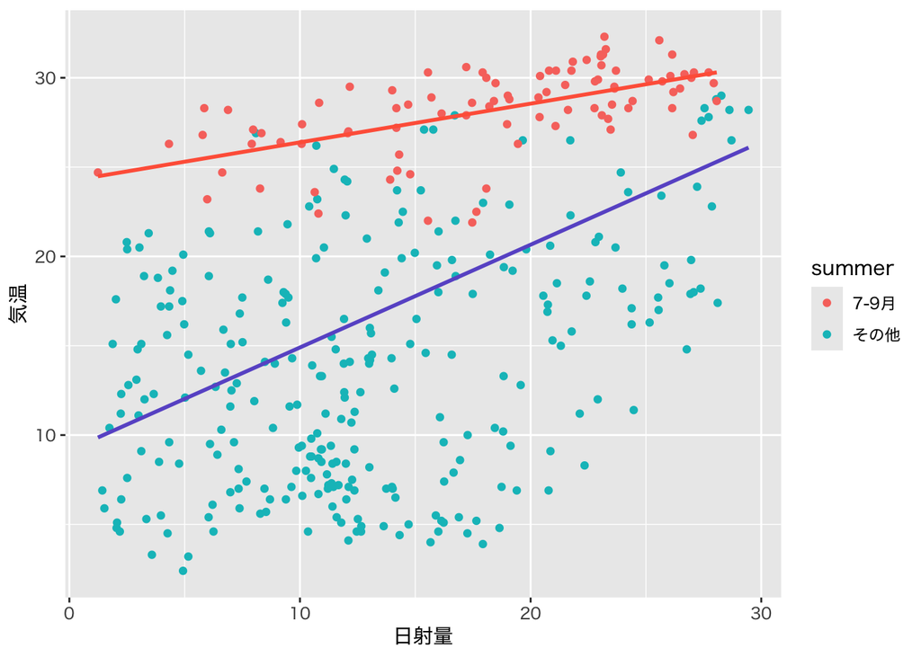

```r
tw_data |>
    mutate(summer = ifelse(month %in% 7:9,
                           "7-9月", # 7月-9月のラベル
                           "その他")) |>
    ggplot(aes(x = solar, y = temp, colour = summer)) +
    geom_point() +
    geom_smooth(method = "lm",
                se = FALSE,
                colour = "slateblue") +
    geom_smooth(data = \(x)filter(x, summer == "7-9月"), # 7-9月に限定
                method = "lm",
                se = FALSE,
                colour = "tomato") +
    labs(x = "日射量", y = "気温")
```

`data` に一変数関数を渡すと関数 `geom_smooth()` 内での処理を限定することができる． 上記は base R での無名関数の記述を用いているが，tidyverse では

```r
~ filter(., summer == "7-9月")
. %>% filter(summer == "7-9月")
```

のように書くこともできる．

## 回帰モデルの区間推定

### 問題

前問で作成した回帰モデルについて区間推定を行いなさい．

### 解答欄

### 解答例

前問で作成した1年分のモデル `tw_lm` を用いて区間推定を行う．

```r
confint(tw_lm)
```

```
                2.5 %     97.5 %
(Intercept) 7.4525750 10.8510360
solar       0.4692685  0.6811405
```

区間推定を視覚化する． 関数 `geom_smooth()` を用いると簡潔に記述できる．

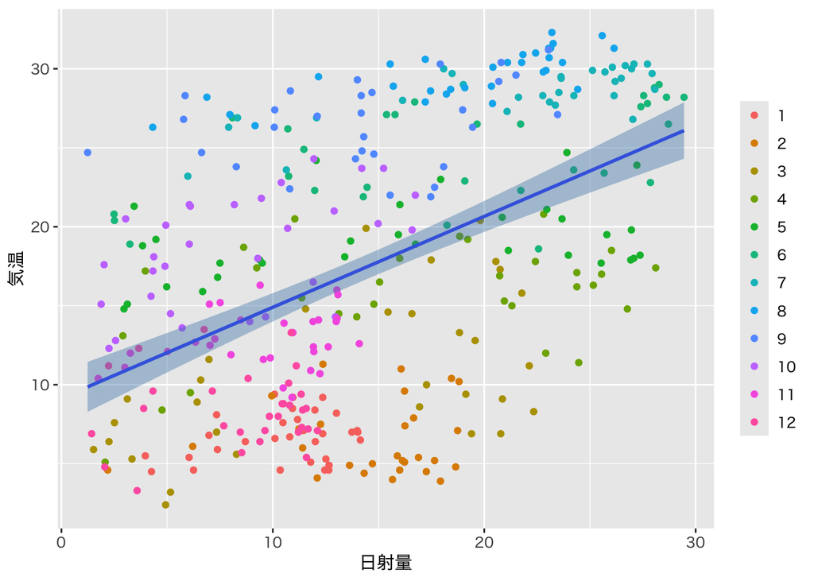

```r
tw_data |>
    ggplot(aes(x = solar, y = temp)) +
    geom_point(aes(colour = factor(month))) + # 月ごとに色を変える
    geom_smooth(method = "lm", # 関数 lm を用いて信頼区間(平滑化方法)を計算
                level = 0.95,  # 既定値なので無くても良い
                colour = "royalblue",  # 線の色
                fill = "steelblue") +  # 塗り潰しの色
    labs(x = "日射量", y = "気温", colour = NULL)
```

上記の描画を愚直に行うには以下のような手続きを考えればよい．

視覚化したい信頼区間に合わせて適切な説明変数と信頼区間を作成する．

```r
tw_conf <-
    tw_lm |>
    augment(newdata = tibble(solar = tw_data |> pull(solar) |>
                                 range() |> # 日射量の範囲を取得
                                 pretty(n = 50)), # 50個程度の区間を作成
            interval = "confidence",
            conf.level = 0.95) # 既定値なので無くてもよい
```

データ点と信頼区間を描画する．

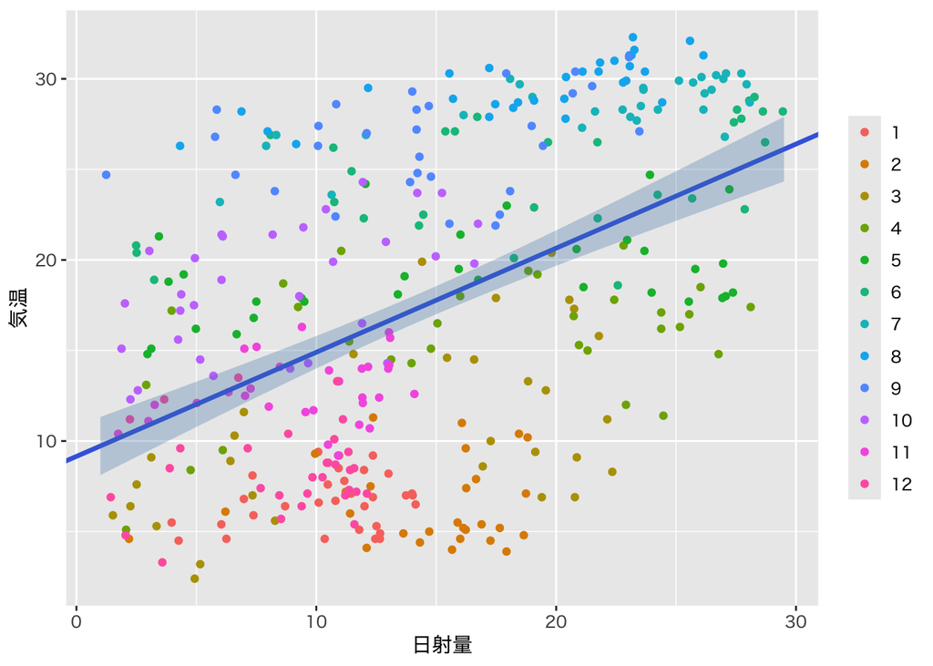

```r
tw_data |>
    ggplot(aes(x = solar, y = temp)) +
    geom_point(aes(colour = factor(month))) +
    geom_abline(intercept = coef(tw_lm)[1],
                slope = coef(tw_lm)[2],
                colour = "royalblue",
                linewidth = 1.2) +
    geom_ribbon(data = tw_conf, # temp 列の代わりに .fitted列がある
                aes(x = solar, y = .fitted,
                    ymin = .lower, ymax = .upper),
                fill = alpha("steelblue", 0.3)) +
    labs(x = "日射量", y = "気温", colour = NULL)
```

データ数がある程度多い場合はデータの説明変数をそのまま用いてもよい．

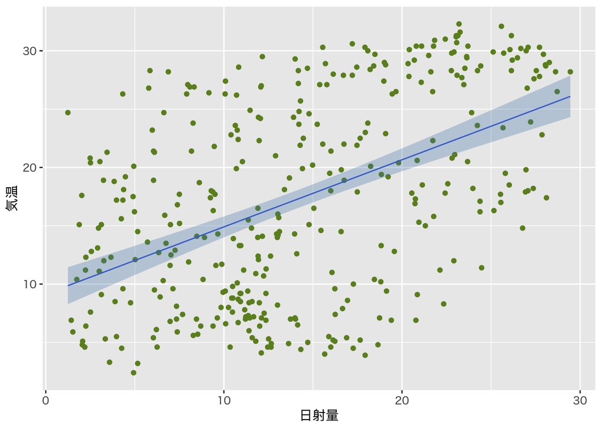

```r
tw_lm |>
    augment(interval = "confidence") |>
    ggplot(aes(x = solar, y = temp)) +
    geom_point(colour = "olivedrab") + # augmentの出力にmonthは含まれていないため
    geom_line(aes(y = .fitted),
              colour = "royalblue") +
    geom_ribbon(aes(ymin = .lower, ymax = .upper),
                fill = alpha("steelblue", 0.3)) +
    labs(x = "日射量", y = "気温")
```

データに信頼区間を追加する方法もある．

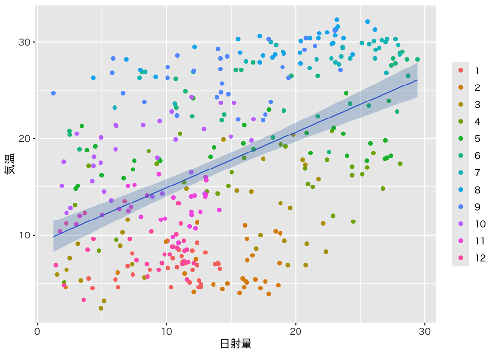

```r
tw_data |>
    mutate(augment(tw_lm, interval = "confidence")) |>
    ggplot(aes(x = solar, y = temp)) +
    geom_point(aes(colour = factor(month))) +
    geom_line(aes(y = .fitted),
              colour = "royalblue") +
    geom_ribbon(aes(ymin = .lower, ymax = .upper),
                fill = alpha("steelblue", 0.3)) +
    labs(x = "日射量", y = "気温", colour = NULL)
```

関数 `predict()` を用いることもできる．

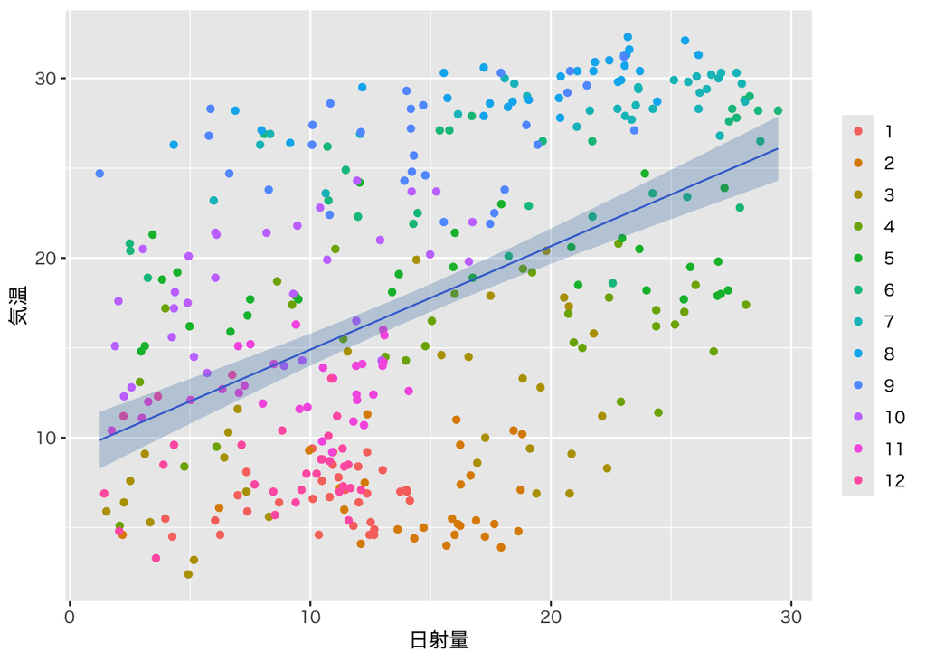

```r
tw_data |>
    mutate(predict(tw_lm, # 推定したモデル
                   interval = "confidence", # 信頼区間の推定を指定
                   level = 0.95) |>
           as_tibble()) |> # tibble形式に変換して追加する (列名に注意)
    ggplot(aes(x = solar, y = temp)) +
    geom_point(aes(colour = factor(month))) + # augmentの出力にmonthは含まれていないため
    geom_line(aes(y = fit), # predict の出力は .fitted でない
              colour = "royalblue") +
    geom_ribbon(aes(ymin = lwr, ymax = upr), # predict の出力は .lower/.upper でない
                fill = alpha("steelblue", 0.3)) +
    labs(x = "日射量", y = "気温", colour = NULL)
```

夏のモデル `tw_lm2` で同様に区間推定を行う．

```r
confint(tw_lm2)
```

```
                 2.5 %     97.5 %
(Intercept) 23.0106720 25.4262244
solar        0.1547671  0.2786862
```

視覚化を行う

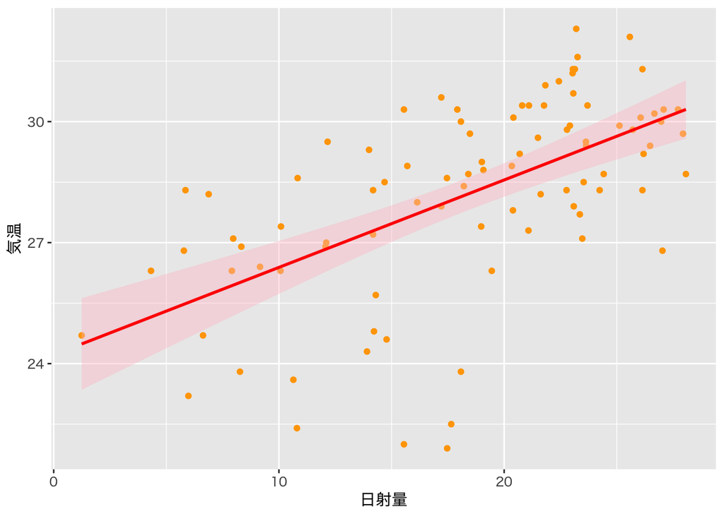

```r
model.frame(tw_lm2) |> # モデルの作成に用いたデータ
    ggplot(aes(x = solar, y = temp)) +
    geom_point(colour = "orange") +
    geom_smooth(method = "lm", level = 0.95,
                colour = "red", fill = "pink") +
    labs(x = "日射量", y = "気温", colour = NULL)
```

1年のデータも重ねて表示する．

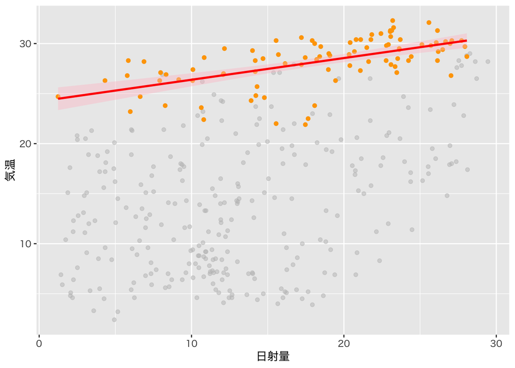

```r
tw_lm2 |>
    augment() |> # この関数でも取り出せる
    ggplot(aes(x = solar, y = temp)) +
    geom_point(data = tw_data, # 1年分のデータを使用
               colour = alpha("grey", 0.5)) + # 薄い灰色で表示
    geom_point(colour = "orange") +
    geom_smooth(method = "lm", level = 0.95,
                colour = "red", fill = "pink") +
    labs(x = "日射量", y = "気温", colour = NULL)
```

1年のデータから限定して信頼区間を描いてもよい．

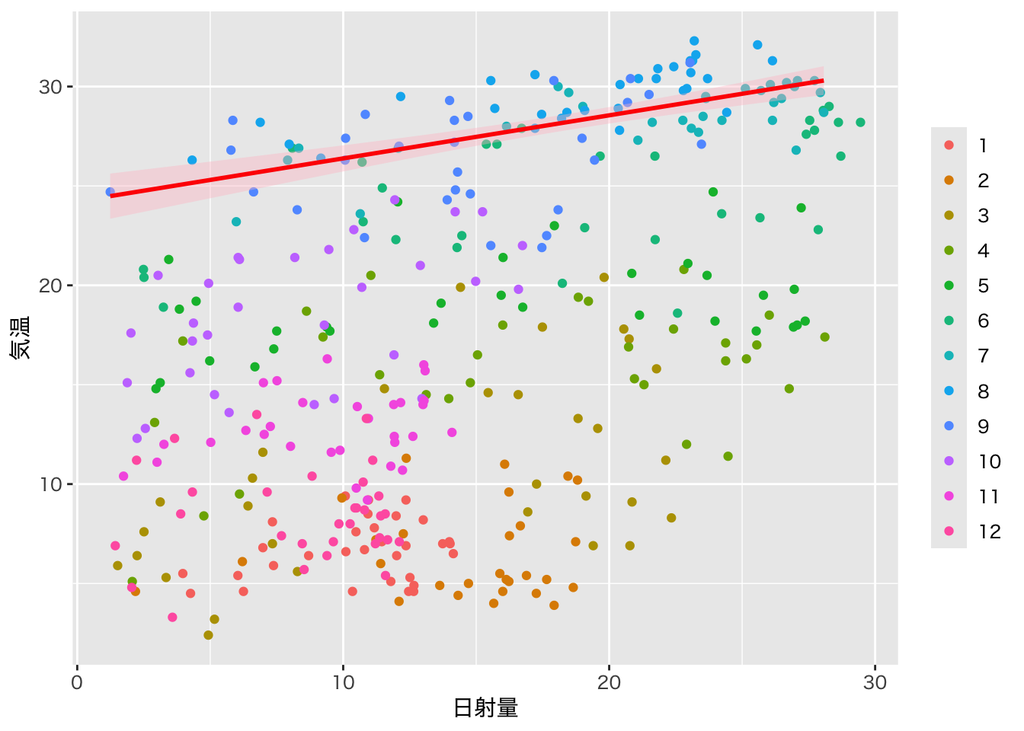

```r
tw_data |>
    ggplot(aes(x = solar, y = temp)) +
    geom_point(aes(colour = factor(month))) +
    geom_smooth(data = \(x)filter(x, month %in% 7:9),
                method = "lm", level = 0.95,
                colour = "red", fill = "pink") +
    labs(x = "日射量", y = "気温", colour = NULL)
```

## 回帰モデルの係数の検定

### 問題

前問で作成した回帰モデルについて係数の検定を行いなさい．

### 解答欄

### 解答例

前問で構成したモデルを用いる． 1年分のモデル `tw_lm` を用いた場合の base R での操作は以下のようになる．

```r
summary(tw_lm)
```

```
Call:
lm(formula = temp ~ solar, data = tw_data)

Residuals:
     Min       1Q   Median       3Q      Max
-15.5652  -6.3738   0.0607   6.2991  15.7832

Coefficients:
            Estimate Std. Error t value Pr(>|t|)
(Intercept)  9.15181    0.86408   10.59   <2e-16 ***
solar        0.57520    0.05387   10.68   <2e-16 ***
---
Signif. codes:  0 '***' 0.001 '**' 0.01 '*' 0.05 '.' 0.1 ' ' 1

Residual standard error: 7.508 on 363 degrees of freedom
Multiple R-squared:  0.239, Adjusted R-squared:  0.2369
F-statistic:   114 on 1 and 363 DF,  p-value: < 2.2e-16
```

情報が多いので，整理してみる

```r
summary(tw_lm)$coef                                  # 名前は識別できれば途中まででも可
```

```
             Estimate Std. Error  t value     Pr(>|t|)
(Intercept) 9.1518055 0.86407966 10.59139 5.071025e-23
solar       0.5752045 0.05386976 10.67769 2.503697e-23
```

```r
summary(tw_lm)$coef["solar",c("t value","Pr(>|t|)")]
```

```
     t value     Pr(>|t|)
1.067769e+01 2.503697e-23
```

```r
summary(tw_lm)$coef[2,3:4]                           # 上と同じ
```

```
     t value     Pr(>|t|)
1.067769e+01 2.503697e-23
```

```r
summary(tw_lm)$fstat                                 # F統計量 (モデルの有意性の評価)
```

```
  value   numdf   dendf
114.013   1.000 363.000
```

```r
anova(tw_lm)$'Pr(>F)'[1]                             # F統計量のp値 (summaryからは取り出し難い)
```

```
[1] 2.503697e-23
```

パイプを使う場合は以下のようにすればよい．

```r
tw_lm |> summary() |> _$coef
```

```
             Estimate Std. Error  t value     Pr(>|t|)
(Intercept) 9.1518055 0.86407966 10.59139 5.071025e-23
solar       0.5752045 0.05386976 10.67769 2.503697e-23
```

```r
tw_lm |> summary() |> _$coef["solar",c("t value","Pr(>|t|)")]
```

```
     t value     Pr(>|t|)
1.067769e+01 2.503697e-23
```

```r
tw_lm |> summary() |> _$coef[2,3:4]
```

```
     t value     Pr(>|t|)
1.067769e+01 2.503697e-23
```

tidyverse での操作は以下のようになる．

```r
tw_lm |> tidy() # 係数の情報をまとめたデータフレーム
```

```
# A tibble: 2 × 5
  term        estimate std.error statistic  p.value
  <chr>          <dbl>     <dbl>     <dbl>    <dbl>
1 (Intercept)    9.15     0.864       10.6 5.07e-23
2 solar          0.575    0.0539      10.7 2.50e-23
```

```r
tw_lm |> tidy() |> # solarの係数のt統計量とp値を抽出
    filter(term == "solar") |> select(statistic, p.value)
```

```
# A tibble: 1 × 2
  statistic  p.value
      <dbl>    <dbl>
1      10.7 2.50e-23
```

```r
tw_lm |> tidy() |> _[2, c("statistic","p.value")]
```

```
# A tibble: 1 × 2
  statistic  p.value
      <dbl>    <dbl>
1      10.7 2.50e-23
```

```r
tw_lm |> tidy() |> _[2,4:5]
```

```
# A tibble: 1 × 2
  statistic  p.value
      <dbl>    <dbl>
1      10.7 2.50e-23
```

```r
tw_lm |> glance() # モデルの情報をまとめたデータフレーム
```

```
# A tibble: 1 × 12
  r.squared adj.r.squared sigma statistic  p.value    df logLik   AIC   BIC
      <dbl>         <dbl> <dbl>     <dbl>    <dbl> <dbl>  <dbl> <dbl> <dbl>
1     0.239         0.237  7.51      114. 2.50e-23     1 -1253. 2511. 2523.
# ℹ 3 more variables: deviance <dbl>, df.residual <int>, nobs <int>
```

```r
tw_lm |> glance() |> # F統計量に関する情報
    select(statistic, p.value, df, df.residual)
```

```
# A tibble: 1 × 4
  statistic  p.value    df df.residual
      <dbl>    <dbl> <dbl>       <int>
1      114. 2.50e-23     1         363
```

夏のモデル `tw_lm2` の base R での操作は以下のようになる．

```r
summary(tw_lm2)
```

```
Call:
lm(formula = formula(tw_lm), data = tw_data, subset = month %in%
    7:9)

Residuals:
    Min      1Q  Median      3Q     Max
-6.1047 -0.8730  0.2343  1.4268  3.0535

Coefficients:
            Estimate Std. Error t value Pr(>|t|)
(Intercept) 24.21845    0.60794  39.837  < 2e-16 ***
solar        0.21673    0.03119   6.949 5.61e-10 ***
---
Signif. codes:  0 '***' 0.001 '**' 0.01 '*' 0.05 '.' 0.1 ' ' 1

Residual standard error: 1.95 on 90 degrees of freedom
Multiple R-squared:  0.3492,    Adjusted R-squared:  0.342
F-statistic: 48.29 on 1 and 90 DF,  p-value: 5.61e-10
```

```r
coef(summary(tw_lm2))              # 関数coefでも可
```

```
              Estimate Std. Error   t value     Pr(>|t|)
(Intercept) 24.2184482 0.60793864 39.836995 5.921203e-59
solar        0.2167267 0.03118757  6.949136 5.609665e-10
```

```r
coef(summary(tw_lm2))["solar",c("t value","Pr(>|t|)")]
```

```
     t value     Pr(>|t|)
6.949136e+00 5.609665e-10
```

```r
coef(tw_lm2)                       # 推定された係数のみ取り出す場合
```

```
(Intercept)       solar
 24.2184482   0.2167267
```

```r
coef(summary(tw_lm2))[,"Estimate"] # 上と同じ
```

```
(Intercept)       solar
 24.2184482   0.2167267
```

tidyverse での操作は以下のようになる．

```r
tw_lm2 |> tidy()   # 係数の情報
```

```
# A tibble: 2 × 5
  term        estimate std.error statistic  p.value
  <chr>          <dbl>     <dbl>     <dbl>    <dbl>
1 (Intercept)   24.2      0.608      39.8  5.92e-59
2 solar          0.217    0.0312      6.95 5.61e-10
```

```r
tw_lm2 |> glance() # モデルの情報
```

```
# A tibble: 1 × 12
  r.squared adj.r.squared sigma statistic  p.value    df logLik   AIC   BIC
      <dbl>         <dbl> <dbl>     <dbl>    <dbl> <dbl>  <dbl> <dbl> <dbl>
1     0.349         0.342  1.95      48.3 5.61e-10     1  -191.  388.  395.
# ℹ 3 more variables: deviance <dbl>, df.residual <int>, nobs <int>
```

## 決定係数による回帰モデルの検討

### 問題

前問で作成した回帰モデルについて 決定係数を確認しなさい． また，説明変数として降水量を用いた回帰モデルについて 検討しなさい．

### 解答欄

### 解答例

前問で構成した1年分のモデル `tw_lm` を用いる．

```r
summary(tw_lm) # 全情報の表示
```

```
Call:
lm(formula = temp ~ solar, data = tw_data)

Residuals:
     Min       1Q   Median       3Q      Max
-15.5652  -6.3738   0.0607   6.2991  15.7832

Coefficients:
            Estimate Std. Error t value Pr(>|t|)
(Intercept)  9.15181    0.86408   10.59   <2e-16 ***
solar        0.57520    0.05387   10.68   <2e-16 ***
---
Signif. codes:  0 '***' 0.001 '**' 0.01 '*' 0.05 '.' 0.1 ' ' 1

Residual standard error: 7.508 on 363 degrees of freedom
Multiple R-squared:  0.239, Adjusted R-squared:  0.2369
F-statistic:   114 on 1 and 363 DF,  p-value: < 2.2e-16
```

```r
summary(tw_lm)$r.squared
```

```
[1] 0.2390145
```

```r
summary(tw_lm)$adj.r.squared
```

```
[1] 0.2369181
```

```r
tw_lm |> glance()
```

```
# A tibble: 1 × 12
  r.squared adj.r.squared sigma statistic  p.value    df logLik   AIC   BIC
      <dbl>         <dbl> <dbl>     <dbl>    <dbl> <dbl>  <dbl> <dbl> <dbl>
1     0.239         0.237  7.51      114. 2.50e-23     1 -1253. 2511. 2523.
# ℹ 3 more variables: deviance <dbl>, df.residual <int>, nobs <int>
```

```r
tw_lm |> glance() |> # 1:2列が決定係数
    select(r.squared, adj.r.squared)
```

```
# A tibble: 1 × 2
  r.squared adj.r.squared
      <dbl>         <dbl>
1     0.239         0.237
```

夏のモデル `tw_lm2` の場合は以下のようになる．

```r
summary(tw_lm2) # 全情報の表示
```

```
Call:
lm(formula = formula(tw_lm), data = tw_data, subset = month %in%
    7:9)

Residuals:
    Min      1Q  Median      3Q     Max
-6.1047 -0.8730  0.2343  1.4268  3.0535

Coefficients:
            Estimate Std. Error t value Pr(>|t|)
(Intercept) 24.21845    0.60794  39.837  < 2e-16 ***
solar        0.21673    0.03119   6.949 5.61e-10 ***
---
Signif. codes:  0 '***' 0.001 '**' 0.01 '*' 0.05 '.' 0.1 ' ' 1

Residual standard error: 1.95 on 90 degrees of freedom
Multiple R-squared:  0.3492,    Adjusted R-squared:  0.342
F-statistic: 48.29 on 1 and 90 DF,  p-value: 5.61e-10
```

```r
summary(tw_lm2)$r.squared
```

```
[1] 0.349196
```

```r
summary(tw_lm2)$adj.r.squared
```

```
[1] 0.3419649
```

```r
tw_lm2 |> glance()
```

```
# A tibble: 1 × 12
  r.squared adj.r.squared sigma statistic  p.value    df logLik   AIC   BIC
      <dbl>         <dbl> <dbl>     <dbl>    <dbl> <dbl>  <dbl> <dbl> <dbl>
1     0.349         0.342  1.95      48.3 5.61e-10     1  -191.  388.  395.
# ℹ 3 more variables: deviance <dbl>, df.residual <int>, nobs <int>
```

```r
tw_lm2 |> glance() |>
    select(r.squared, adj.r.squared)
```

```
# A tibble: 1 × 2
  r.squared adj.r.squared
      <dbl>         <dbl>
1     0.349         0.342
```

降水量と気温の関係を調べる．

```r
tw_lm3 <- lm(temp ~ rain, data = tw_data)
tw_lm4 <- lm(formula(tw_lm3), # 上の式を用いる
             data = tw_data,
             subset = month %in% 7:9) # 夏(7-9月)のモデル
```

1年分のモデル `tw_lm3` を調べる．

```r
tw_lm3 |> summary()
```

```
Call:
lm(formula = temp ~ rain, data = tw_data)

Residuals:
     Min       1Q   Median       3Q      Max
-14.9188  -8.0918  -0.0714   8.9140  14.9082

Coefficients:
            Estimate Std. Error t value Pr(>|t|)
(Intercept) 17.39182    0.47791  36.391   <2e-16 ***
rain        -0.00730    0.05054  -0.144    0.885
---
Signif. codes:  0 '***' 0.001 '**' 0.01 '*' 0.05 '.' 0.1 ' ' 1

Residual standard error: 8.606 on 363 degrees of freedom
Multiple R-squared:  5.746e-05, Adjusted R-squared:  -0.002697
F-statistic: 0.02086 on 1 and 363 DF,  p-value: 0.8852
```

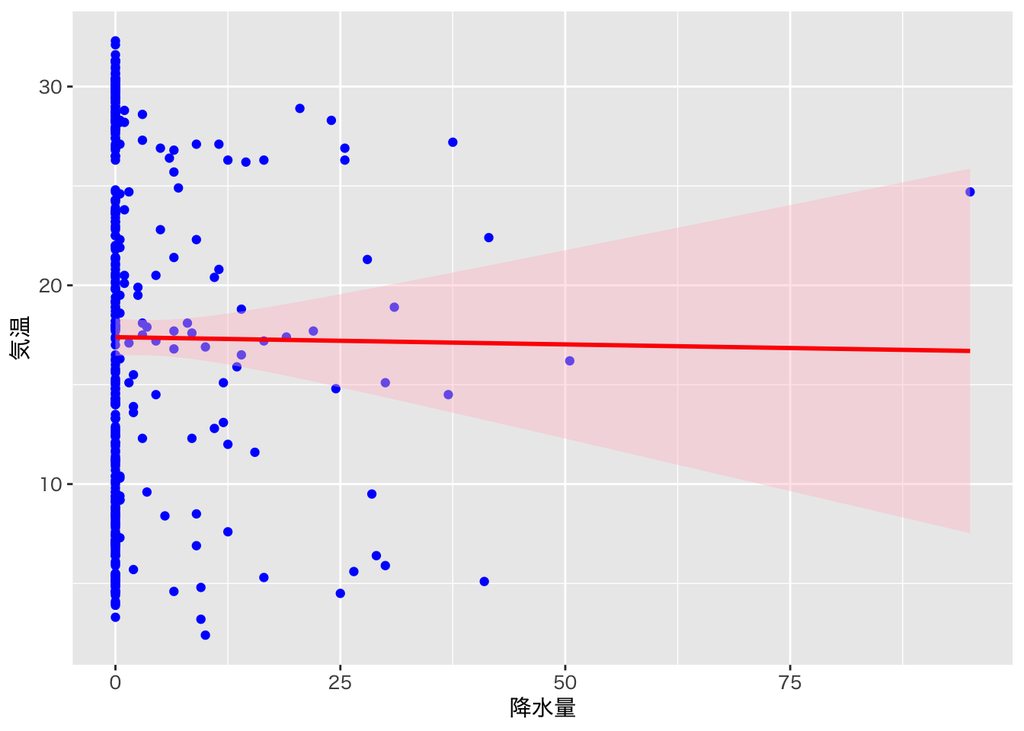

```r
model.frame(tw_lm3) |> # 推定に用いたデータを利用
    ggplot(aes(x = rain, y = temp)) +
    geom_point(colour = "blue") +
    geom_smooth(method = "lm",
                colour = "red", fill = "pink") +
    labs(x = "降水量", y = "気温")
```

1年分のモデル `tw_lm3` に有意性はないことがわかる．

夏のモデル `tw_lm4` を調べる．

```r
tw_lm4 |> summary()
```

```
Call:
lm(formula = formula(tw_lm3), data = tw_data, subset = month %in%
    7:9)

Residuals:
    Min      1Q  Median      3Q     Max
-6.5167 -1.0167  0.3196  1.6678  3.8833

Coefficients:
            Estimate Std. Error t value Pr(>|t|)
(Intercept) 28.41666    0.25175 112.876  < 2e-16 ***
rain        -0.05752    0.01960  -2.935  0.00423 **
---
Signif. codes:  0 '***' 0.001 '**' 0.01 '*' 0.05 '.' 0.1 ' ' 1

Residual standard error: 2.309 on 90 degrees of freedom
Multiple R-squared:  0.08736,   Adjusted R-squared:  0.07722
F-statistic: 8.615 on 1 and 90 DF,  p-value: 0.00423
```

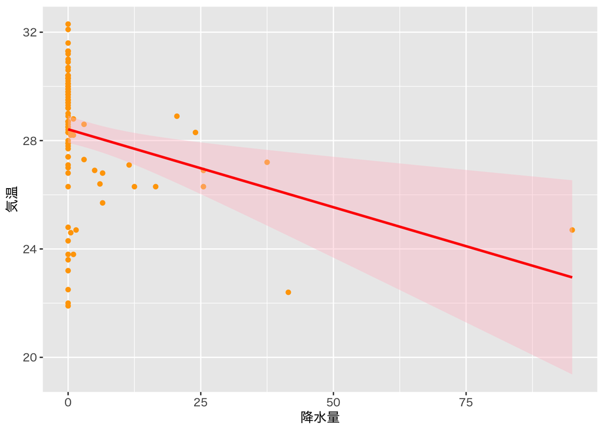

```r
model.frame(tw_lm4) |> # 推定に用いたデータを利用
    ggplot(aes(x = rain, y = temp)) +
    geom_point(colour = "orange") +
    geom_smooth(method = "lm",
                colour = "red", fill = "pink") +
    labs(x = "降水量", y = "気温")
```

夏場は雨が降ると気温が下がる傾向が有意にあることが読み取れる． 決定係数が低いのはそもそも気温のばらつきが大きいことに起因すると考えられる．

## 補遺

### `ggplot2` を用いた線形回帰分析(単回帰)の例

```r
#' パッケージの読み込み
#' 以下のほかに 'ggrepel' 'broom' 'magrittr' 'MASS' を利用
library(tidyverse)
library(ggfortify)
```

データの読み込み (“MASS::Animals”を用いる) を行う．

```r
data(Animals, package = "MASS")
```

以下 `Animals` で参照可能となる．

データの内容を確認する．

```r
help(Animals, package = "MASS") # 内容の詳細を表示
print(Animals)                  # データの表示
```

```
                      body  brain
Mountain beaver      1.350    8.1
Cow                465.000  423.0
Grey wolf           36.330  119.5
Goat                27.660  115.0
Guinea pig           1.040    5.5
Dipliodocus      11700.000   50.0
Asian elephant    2547.000 4603.0
Donkey             187.100  419.0
Horse              521.000  655.0
Potar monkey        10.000  115.0
Cat                  3.300   25.6
Giraffe            529.000  680.0
Gorilla            207.000  406.0
Human               62.000 1320.0
African elephant  6654.000 5712.0
Triceratops       9400.000   70.0
Rhesus monkey        6.800  179.0
Kangaroo            35.000   56.0
Golden hamster       0.120    1.0
Mouse                0.023    0.4
Rabbit               2.500   12.1
Sheep               55.500  175.0
Jaguar             100.000  157.0
Chimpanzee          52.160  440.0
Rat                  0.280    1.9
Brachiosaurus    87000.000  154.5
Mole                 0.122    3.0
Pig                192.000  180.0
```

データのプロット (normal plot) を行う．

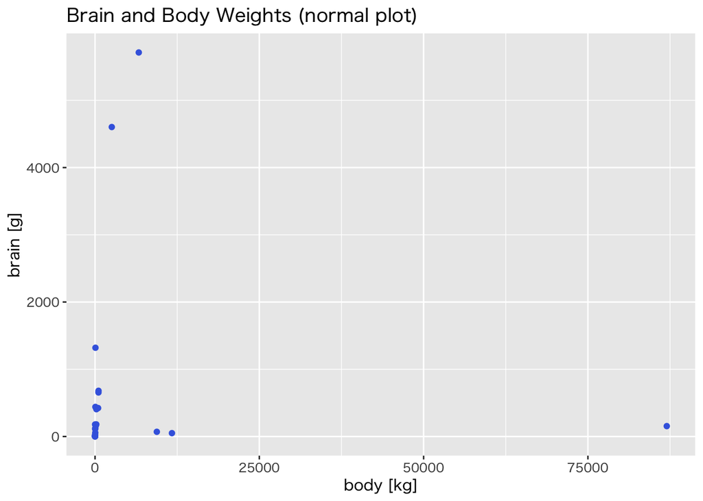

```r
Animals |>
    ggplot(aes(body, brain)) + # x軸，y軸に用いる列の指定
    geom_point(colour = "royalblue") + # 点の追加
    labs(title = "Brain and Body Weights (normal plot)",
         x = "body [kg]", y = "brain [g]") # タイトルと軸名の追加
```

データのプロット (log plot) を行う．

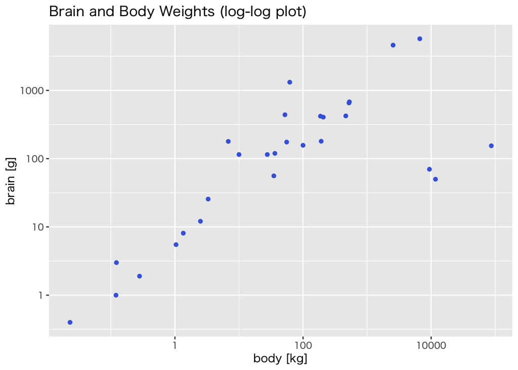

```r
Animals |>
    ggplot(aes(body, brain)) +
    geom_point(colour = "royalblue") +
    scale_x_log10() + scale_y_log10() + # log-log plot を指定
    labs(title = "Brain and Body Weights (log-log plot)",
         x = "body [kg]", y="brain [g]")
```

データの分布から両対数変換が分析においては適切であることがわかる．

回帰分析 (単回帰) を行う．

```r
bb_lm <- lm(log(brain) ~ log(body), # 対数変換した変数で線形回帰
            data = Animals)
bb_lm |> summary() # 分析結果のまとめを表示
```

```
Call:
lm(formula = log(brain) ~ log(body), data = Animals)

Residuals:
    Min      1Q  Median      3Q     Max
-3.2890 -0.6763  0.3316  0.8646  2.5835

Coefficients:
            Estimate Std. Error t value Pr(>|t|)
(Intercept)  2.55490    0.41314   6.184 1.53e-06 ***
log(body)    0.49599    0.07817   6.345 1.02e-06 ***
---
Signif. codes:  0 '***' 0.001 '**' 0.01 '*' 0.05 '.' 0.1 ' ' 1

Residual standard error: 1.532 on 26 degrees of freedom
Multiple R-squared:  0.6076,    Adjusted R-squared:  0.5925
F-statistic: 40.26 on 1 and 26 DF,  p-value: 1.017e-06
```

信頼区間付きで回帰式を表示する．

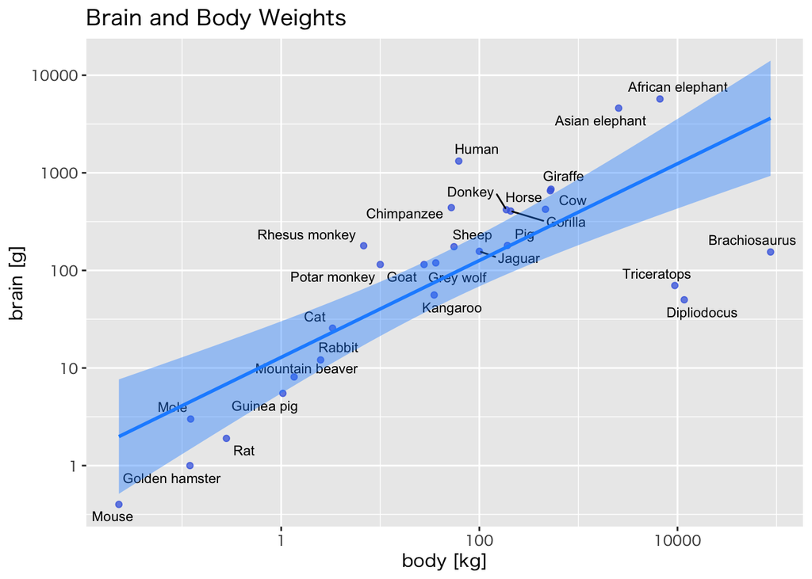

```r
Animals |>
    rownames_to_column() |>
    ggplot(aes(body, brain)) +
    geom_point(colour = alpha("royalblue", 0.75)) +
    ggrepel::geom_text_repel(aes(label = rowname), # 各点の名前を追加
                             size = 3) +
    geom_smooth(method = "lm", # 回帰式
                colour = "dodgerblue",
                fill = "dodgerblue") +
    scale_x_log10() + scale_y_log10() + # log-log plot
    labs(title = "Brain and Body Weights",
         x = "body [kg]", y = "brain [g]")
```

信頼区間および予測区間付きで回帰式を表示する．

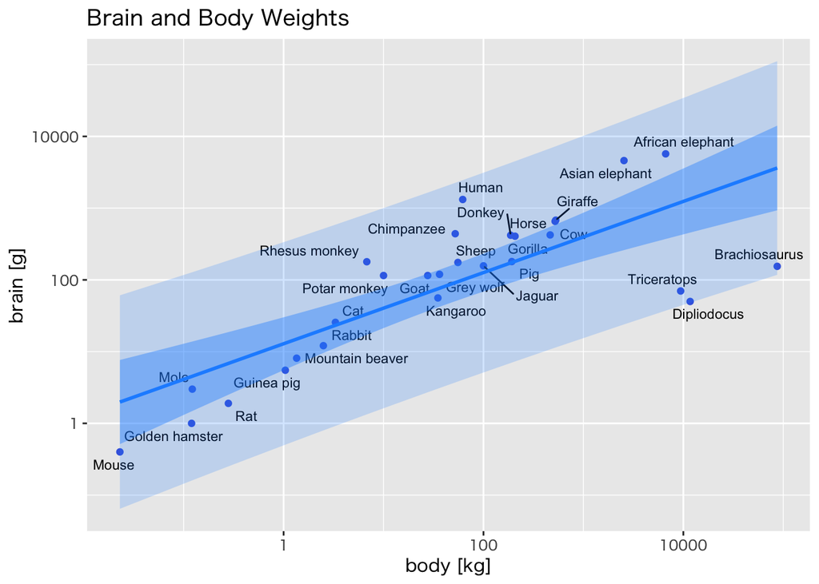

```r
Animals |>
    rownames_to_column() |>
    mutate( # 予測区間の情報を追加する
        augment(bb_lm,
                       interval = "prediction", # 予測区間を指定
                       conf.level = 0.95) |>    # 既定値なので省略可能
        select(.fitted, .lower, .upper) |> exp() # 必要な列を選択して対数変換を戻す
    ) |>
    ggplot(aes(body, brain)) +
    geom_point(colour = "royalblue") +
    ggrepel::geom_text_repel(aes(label = rowname), # 各点の名前を追加
                             size = 3) + # 文字の大きさを調整
    geom_smooth(method = "lm", # 回帰式
                colour = "dodgerblue",
                fill = "dodgerblue") +
    geom_ribbon(aes(ymin = .lower, ymax = .upper), # 予測区間の描画
                fill = alpha("dodgerblue", 0.2)) +
    scale_x_log10() + scale_y_log10() + # log-log plot
    labs(title = "Brain and Body Weights",
         x = "body [kg]", y = "brain [g]")
```

予測区間の計算は関数 `predict()` を用いてもよい．

```r
mutate( # 予測区間の情報を追加する
    predict(bb_lm,
            newdata = Animals, # 対数変換のため指定しないと警告が出る
            interval = "prediction") |>
    exp() |>    # 対数変換を戻す
    as_tibble() # tibble形式でfit/lwr/upr列を追加
)
```

診断プロットを表示する．

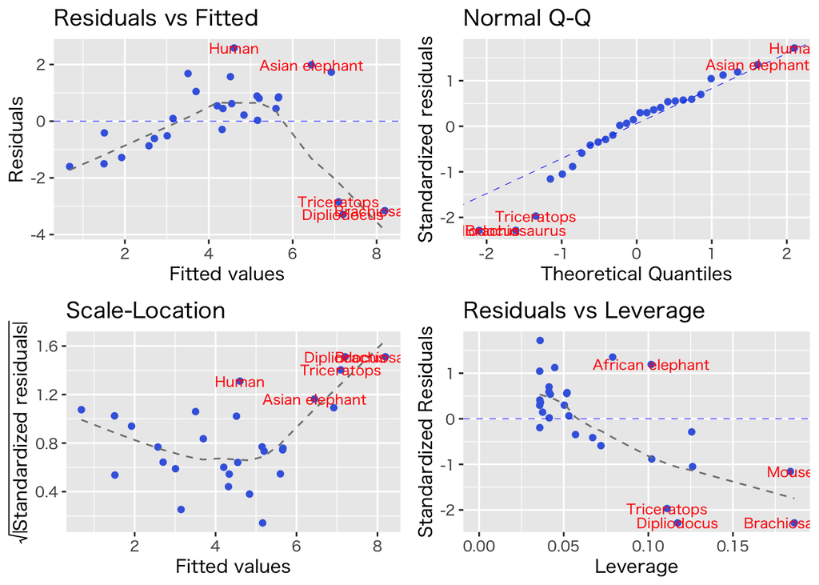

```r
autoplot(bb_lm,
         colour = "royalblue",
         smooth.colour = "gray50",
         smooth.linetype = "dashed",
         ad.colour = "blue",
         label.size = 3,      # 以下，外れ値ラベルに関する設定
         label.n = 5,
         label.colour = "red")
```

外れ値を除いた回帰分析を行う．

```r
idx <- c(6,16,26) # 外れ値のindex (いずれも恐竜)
bb_lm <- lm(log(brain) ~ log(body),
            data = Animals,
            subset = -idx) # 外れ値を除く
bb_lm |> summary()
```

```
Call:
lm(formula = log(brain) ~ log(body), data = Animals, subset = -idx)

Residuals:
    Min      1Q  Median      3Q     Max
-0.9125 -0.4752 -0.1557  0.1940  1.9303

Coefficients:
            Estimate Std. Error t value Pr(>|t|)
(Intercept)  2.15041    0.20060   10.72 2.03e-10 ***
log(body)    0.75226    0.04572   16.45 3.24e-14 ***
---
Signif. codes:  0 '***' 0.001 '**' 0.01 '*' 0.05 '.' 0.1 ' ' 1

Residual standard error: 0.7258 on 23 degrees of freedom
Multiple R-squared:  0.9217,    Adjusted R-squared:  0.9183
F-statistic: 270.7 on 1 and 23 DF,  p-value: 3.243e-14
```

信頼区間および予測区間付き回帰式を表示する．

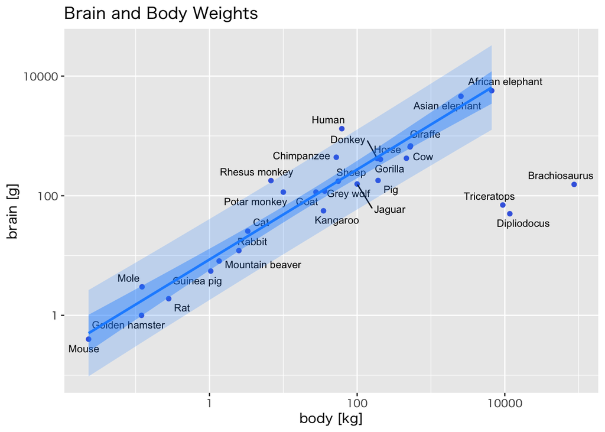

```r
Animals |>
    rownames_to_column() |>
    mutate(
        augment(bb_lm,
                       newdata = Animals, # 外れ値を除いたので全データで計算
                       interval = "prediction") |>
        select(.fitted, .lower, .upper) |> exp()) |>
    ggplot(aes(body, brain)) +
    geom_point(colour = "royalblue") +
    ggrepel::geom_text_repel(aes(label = rowname), # 各点の名前を追加
                             size = 3) + # 文字の大きさを調整
    geom_smooth(data = \(x)slice(x, -idx), # 外れ値を除く
                method = "lm", # 回帰式
                colour = "dodgerblue",
                fill = "dodgerblue") +
    geom_ribbon(data = \(x)slice(x, -idx), # 外れ値を除く
                aes(ymin = .lower, ymax = .upper), # 予測区間の描画
                fill = alpha("dodgerblue", 0.2)) +
    scale_x_log10() + scale_y_log10() + # log-log plot
    labs(title = "Brain and Body Weights",
         x = "body [kg]", y = "brain [g]")
```

恐竜の領域でも信頼・予測区間を描画するには，少し工夫が必要となる．

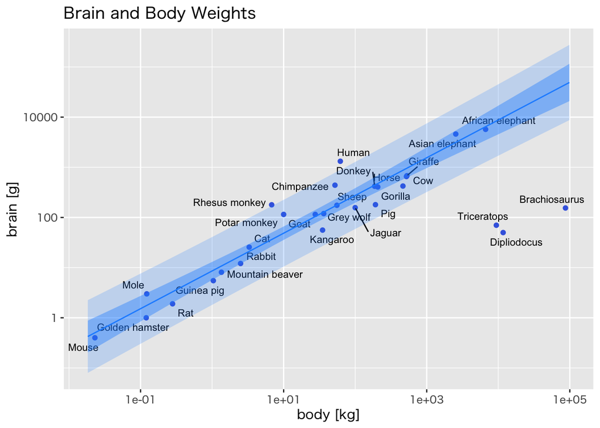

```r
bb_new_body <- # 計算用のbody列を作成
    tibble(body = Animals |> pull(body) |>
               log() |> pretty(n=32) |> exp())
bb_new_data <- # 作成したbody列に対する区間の計算
    tibble(bb_new_body,
           augment(bb_lm,
                          newdata = bb_new_body,
                          interval = "confidence") |> # 信頼区間
           select(.fitted, .lower, .upper) |> exp() |>
           set_names(c("brain","c.lower","c.upper")), # 列名の指定
           augment(bb_lm,
                          newdata = bb_new_body,
                          interval = "prediction") |> # 予測区間
           select(.lower, .upper) |> exp() |>
           set_names(c("p.lower","p.upper"))) # 列名の指定
Animals |>
    rownames_to_column() |>
    ggplot(aes(body, brain)) +
    geom_point(colour = "royalblue") +
    ggrepel::geom_text_repel(aes(label = rowname),
                             size = 3) +
    geom_line(data = bb_new_data,                    # 回帰式の描画
              colour = "dodgerblue") +
    geom_ribbon(data = bb_new_data,
                aes(ymin = c.lower, ymax = c.upper), # 信頼区間の描画
                fill = alpha("dodgerblue", 0.4)) +
    geom_ribbon(data = bb_new_data,
                aes(ymin = p.lower, ymax = p.upper), # 予測区間の描画
                fill = alpha("dodgerblue", 0.2)) +
    scale_x_log10() + scale_y_log10() +
    labs(title = "Brain and Body Weights",
         x = "body [kg]", y = "brain [g]")
```

診断プロットを表示する．

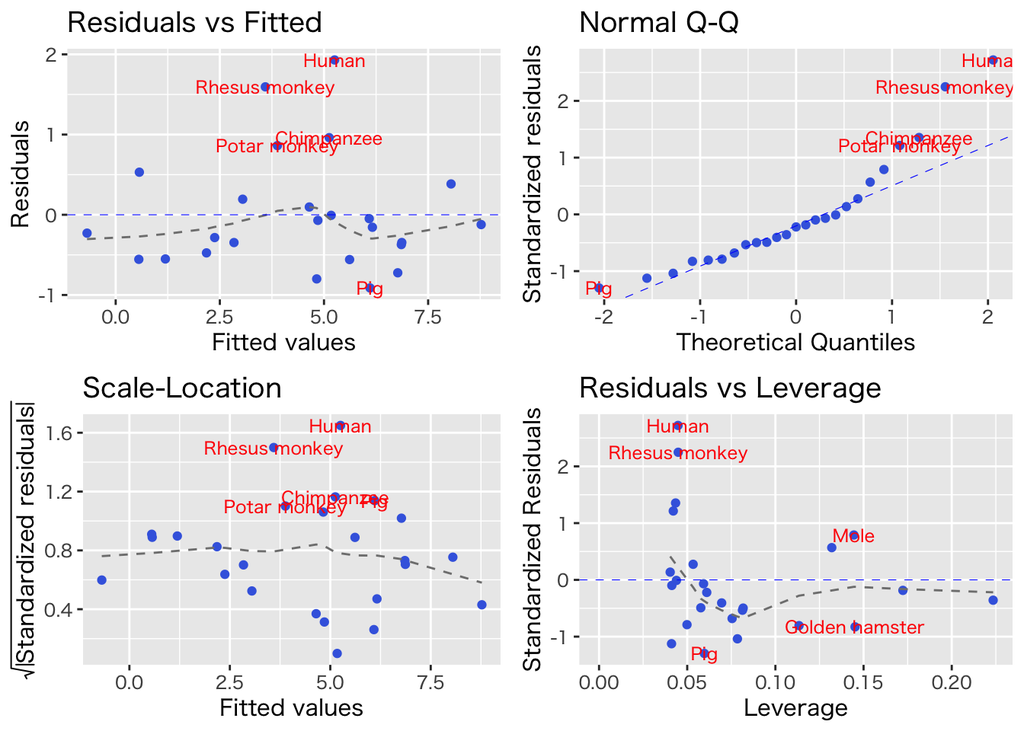

```r
autoplot(bb_lm,
         colour = "royalblue",
         smooth.colour = "gray50",
         smooth.linetype = "dashed",
         ad.colour = "blue",
         label.size = 3,      # 以下，外れ値ラベルに関する設定
         label.n = 5,
         label.colour = "red")
```